# Lake Water Quality Analysis

Keian Freshwater

23 February, 2022

# LAGOS Analysis

## Loading in data

### First download and then specifically grab the locus (or site lat longs)

```r
#Lagos download script
#lagosne_get(dest_folder = LAGOSNE:::lagos_path(),overwrite=T)

#Load in lagos
lagos <- lagosne_load()


#Grab the lake centroid info
lake_centers <- lagos$locus

# Make an sf object
spatial_lakes <- st_as_sf(lake_centers,coords=c('nhd_long','nhd_lat'),
                          crs=4326)

#Grab the water quality data
nutr <- lagos$epi_nutr

#Look at column names
#names(nutr)
```

### Subset columns nutr to only keep key info that we want

```r
clarity_only <- nutr %>%
  select(lagoslakeid,sampledate,chla,doc,secchi) %>%
  mutate(sampledate = as.character(sampledate) %>% ymd(.))
```

### Keep sites with at least 200 observations

```r
#Look at the number of rows of dataset
#nrow(clarity_only)

chla_secchi <- clarity_only %>%
  filter(!is.na(chla),
         !is.na(secchi))

# How many observatiosn did we lose?
# nrow(clarity_only) - nrow(chla_secchi)


# Keep only the lakes with at least 200 observations of secchi and chla
chla_secchi_200 <- chla_secchi %>%
  group_by(lagoslakeid) %>%
  mutate(count = n()) %>%
  filter(count > 200)
```

### Join water quality data to spatial data

```r
spatial_200 <- inner_join(spatial_lakes,chla_secchi_200 %>%
                            distinct(lagoslakeid,.keep_all=T),
                          by='lagoslakeid')
```

### Mean Chl_a map

```r
### Take the mean chl_a and secchi by lake

mean_values_200 <- chla_secchi_200 %>%
  # Take summary by lake id
  group_by(lagoslakeid) %>%
  # take mean chl_a per lake id
  summarize(mean_chl = mean(chla,na.rm=T),
            mean_secchi=mean(secchi,na.rm=T)) %>%
  #Get rid of NAs
  filter(!is.na(mean_chl),
         !is.na(mean_secchi)) %>%
  # Take the log base 10 of the mean_chl
  mutate(log10_mean_chl = log10(mean_chl))

#Join datasets
mean_spatial <- inner_join(spatial_lakes,mean_values_200,
                          by='lagoslakeid')

#Make a map
mapview(mean_spatial,zcol='log10_mean_chl')
```

[interactive chart not shown]

# Class work

## 1) What is the correlation between Secchi Disk Depth and Chlorophyll a for sites with at least 200 observations?

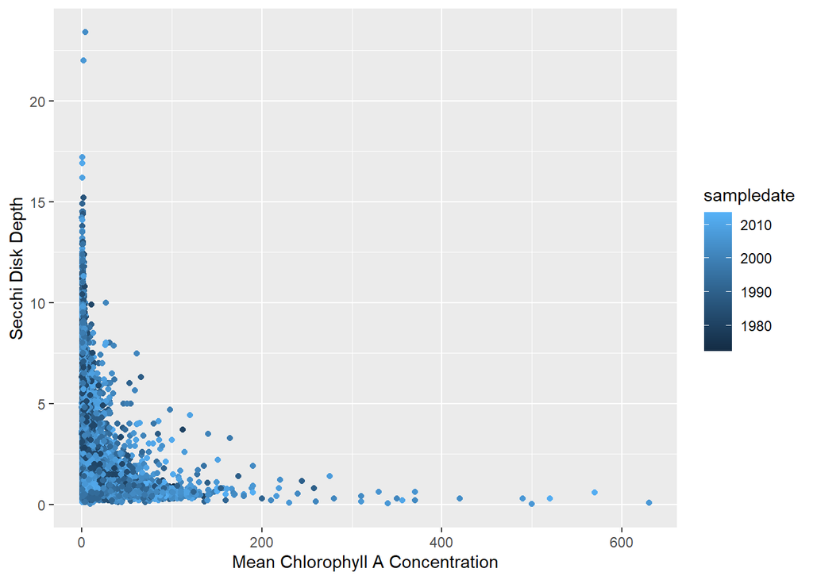

```r
ggplot(data=chla_secchi_200,aes(x=chla,y=secchi,color= sampledate)) +
  geom_point() +
  xlab('Mean Chlorophyll A Concentration') +
  ylab('Secchi Disk Depth')
```

In general, a high secchi disk depth is correlated to virtually 0 mean Chlorophyll A concentration; the mean Chlorophyll A concentration is highest at secchi disk depth of 0.

## Why might this be the case?

Chlorophyll is used by plants and algae in the process of photosynthesis. When there is no light (i.e. clouded water characterized by a high Secchi Disk depth), organisms with Cholorophyll A cannot maintain life, This is why the highest mean Chlorophyll A concentrations are found solely at a Secchi disk depth of 0.

## 2) What states have the most data?

```r
#count by zone ID
counts_site <- lake_centers %>%
  group_by(lagoslakeid) %>%
  mutate(count = n()) %>%
  summarize(count=count,
            state_zoneid)

#match zone_ID to state name
counts_state_IDs <- inner_join(counts_site,lagos$state,by="state_zoneid")

#sum counts, then isolate state names and number of data points
sum_states <- counts_state_IDs %>%
  group_by(state_name) %>%
  summarize(number_of_observations = sum(count),
            state_name=state_name,) %>%
  distinct(state_name,.keep_all=T) %>%
  arrange(desc(number_of_observations))

#print table
knitr::kable(sum_states,col.names=c('State Name', 'Number of Data Points'))
```

| State Name | Number of Data Points |
| --- | --- |
| Minnesota | 29022 |
| Michigan | 15569 |
| Wisconsin | 13790 |
| New York | 11950 |
| Illinois | 11805 |
| Missouri | 9116 |
| Indiana | 7942 |
| Ohio | 6120 |
| Pennsylvania | 5922 |
| Maine | 5518 |
| Iowa | 4636 |
| Massachusetts | 3912 |
| New Jersey | 3333 |
| New Hampshire | 2544 |
| Connecticut | 2025 |
| Vermont | 1626 |
| Rhode Island | 618 |

Minnesota has the most data points, at 29,022. Rhode Island has the fewest data points, at 618.

## 3) Is there a spatial pattern in Secchi disk depth for lakes with at least 200 observations?

```r
mean_spatial %>%
  rename(mean_secchi_depth = mean_secchi) %>%
  arrange(-mean_secchi_depth) %>%
  mapview(.,zcol = 'mean_secchi_depth', canvas=TRUE)
```

[interactive chart not shown]

For lakes with over 200 observations, mean secchi depths in the midwest, with the exception of Wisconsin, tend to be low. On the other hand, for lakes with over 200 observations, the highest depths are in the Northeast/New England. For example, the highest secchi disk depth is near the NY-VT border.